# Clinical Research

Biostatistics

- design of experiments in clinical trials
- power of the statistical test
- type I and type II error
- multiplicity
- sample size estimation in clinical trials
- endpoints in clinical trial
- survival analysis
- confidence intervals
- pvalue
- ICH E9
- FDA adaptive design guideline
- FDA multiple endpoints guideline
- EMA pointa to consider on multiplicity
- EMA subgroup analysis guideline.

# Design of experiments in clinical trials

Clinical trials are essential in the development of new treatments and medicines. The design of experiments (DOE) in clinical trials plays a critical role in determining the effectiveness and safety of new treatments. There are several key components to consider when designing experiments for clinical trials:

```
- Study Population: This involves defining the patient population to be included in the study, such as age, gender, and medical history.

- Intervention: The intervention being tested, such as a new drug or a new surgical procedure, must be well defined and standardized.

- Outcome Measures: The outcome measures used to evaluate the effectiveness of the intervention must be clearly defined and relevant to the population being studied.

- Control Group: A control group is necessary to establish a baseline for comparison and to determine the effectiveness of the intervention. The control group may receive a placebo or standard of care treatment.

- Randomization: To eliminate bias, participants in clinical trials are often randomly assigned to the intervention or control group.

- Blinding: Blinding, or masking, is used to minimize the potential for bias. In double-blind trials, neither the patient nor the investigator knows which group the patient has been assigned to.

- Sample Size: The sample size must be large enough to provide sufficient statistical power to detect a difference between the intervention and control groups.

- Statistical Analysis: The data collected in a clinical trial must be analyzed using appropriate statistical methods to determine the effectiveness of the intervention.
```

The design of experiments in clinical trials is a complex and critical process. It requires careful consideration of many factors to ensure that the results are reliable, valid, and can be used to inform clinical practice.

```
1. Types of Clinical Trials: There are several types of clinical trials, including randomized controlled trials (RCTs), observational studies, and crossover trials. The design of each type of trial will vary depending on the research question and the type of intervention being tested.

2. Stratified Randomization: In some trials, participants may be stratified into subgroups based on characteristics such as age, gender, or medical history. This ensures that the intervention and control groups are balanced with respect to these factors, which can impact the results of the trial.

3. Adaptive Designs: Adaptive designs allow the trial design to be modified based on the results of the trial as it is being conducted. This can make it possible to address new questions or make changes to the trial protocol without having to start the trial over from the beginning.

4. Placebo-Controlled Trials: Placebo-controlled trials are often used to determine the effectiveness of a new intervention. In these trials, a portion of the participants receive a placebo (an inactive treatment), while the rest receive the active intervention being tested. The results from the two groups are then compared.

5. Crossover Trials: In crossover trials, participants receive both the intervention and the control (placebo or standard of care) in a random order. This design can be useful when the intervention has a short-term effect that can be measured quickly.

6. Blinding in Clinical Trials: Blinding is used to minimize the potential for bias in clinical trials. In addition to double-blinding, there may also be single-blinding, where only the patient or only the investigator is blinded to the treatment group assignment.

7. Monitoring Clinical Trials: Clinical trials are typically monitored by an independent group to ensure the safety of participants and the integrity of the data. This group may include a data and safety monitoring board (DSMB) or a data monitoring committee (DMC).

8. Data Management in Clinical Trials: The data collected in clinical trials must be managed in a way that ensures its accuracy, completeness, and integrity. This may include the use of electronic data capture systems and centralized data management centers.
```

# Power of the statistical tests

The power of a statistical test is *the probability that it will correctly lead to the rejection of a null hypothesis (H0) when it is false*

```
1. Type 1 error: A Type 1 error, also known as a false positive
2. Type 2 error: A Type 2 error, also known as a false negative
```

In clinical trials, a **Type 1 error can lead to false positive results and the approval of ineffective treatments**, while a **Type 2 error can result in false negative results and the rejection of potentially effective treatments**. By carefully designing and conducting clinical trials, researchers can minimize the risk of both Type 1 and Type 2 errors and ensure that their results are accurate and reliable.

# Multiplicity

Multiplicity refers to the situation where you are testing multiple hypotheses or making multiple comparisons on the same data. In other words, it means that you are performing multiple tests on the same information.

The problem with multiplicity is that it increases the risk of finding a significant result by chance, simply due to the large number of tests performed. This can lead to false positive results, where you believe that a relationship exists when it actually does not.

For example, imagine you are conducting a clinical trial and you want to test the effectiveness of a new drug on multiple outcomes, such as blood pressure, cholesterol, and weight. If you perform a separate test for each outcome, the risk of finding a significant result by chance increases with each additional test.

To address the problem of multiplicity, it's important to use statistical methods that account for the multiple comparisons being made and to control the risk of false positive results. This can include techniques such as the *Bonferroni correction*, controlling the *family-wise error rate*, or using the *false discovery rate (FDR)*.

- *Bonferroni Correction*: The Bonferroni correction is a simple and straightforward method for controlling the family-wise error rate in multiple comparisons. The idea behind the Bonferroni correction is to divide the significance level (e.g., alpha) by the number of tests being performed. This results in a more stringent criterion for significance, which reduces the risk of finding a false positive result by chance.
  - For example, if you were conducting 10 tests and wanted to control the family-wise error rate at alpha=0.05, the Bonferroni correction would divide the significance level by 10, resulting in a new significance level of 0.005 (0.05/10). Any results that are significant at this new, more stringent level are considered to be true positive results.
- *Family-wise Error Rate*: The family-wise error rate (FWER) is the probability of making at least one false positive error in a set of multiple comparisons. The FWER is often used as a measure of the overall type I error rate when making multiple comparisons, and is typically controlled using methods such as the Bonferroni correction or false discovery rate (FDR).
  - To calculate the FWER, you would first specify the significance level (e.g., alpha) for each individual comparison. Then, you would calculate the probability of obtaining a significant result for each comparison under the assumption that the null hypothesis is true. Finally, you would combine these probabilities to estimate the overall probability of making at least one false positive error.
- *False Discovery Rate*: The false discovery rate (FDR) is a measure of the proportion of false positive results among all significant results. The FDR is a more powerful method than the Bonferroni correction for controlling the family-wise error rate, as it allows for the discovery of more true positive results while still controlling the proportion of false positive results.

# Sample Size Estimation

- Two-Sample t-Test: For a two-sample t-test, the sample size formula is given by:
  - n = (2 *SD^2* Z^2) / d^2

    where n is the sample size for each group, SD is the standard deviation of the outcome measure, Z is the Z-score corresponding to the desired level of power, and d is the effect size of interest
- One-Sample t-Test: For a one-sample t-test, the sample size formula is given by:
  - n = (SD^2 * Z^2) / d^2

    where n is the sample size, SD is the standard deviation of the outcome measure, Z is the Z-score corresponding to the desired level of power, and d is the effect size of interest
- Proportions: For a comparison of proportions, the sample size formula is given by:
  - n = (Z^2 *p* (1-p)) / d^2

    where n is the sample size for each group, Z is the Z-score corresponding to the desired level of power, **p is the proportion of the population** with the outcome of interest, and d is the effect size of interest or **error**

Z-score

- 70% 1.04
- 75% 1.15
- 80% 1.28
- 85% 1.44
- 90% 1.645
- 95% 1.96
- 99% 2.57
- 99.99% 3.89

```python
import math
from scipy.stats import norm

def sample_size(SD, d, alpha):
    Z = norm.ppf(1-alpha/2)
    n = (2 * (SD**2) * (Z**2)) / (d**2)
    return int(math.ceil(n))

SD = 1
d = 0.2 #difference between two groups
alpha = 0.01

sample_size = sample_size(SD, d, alpha)
print("Sample size:", sample_size)
```

```
Sample size: 332
```

```python
from scipy.stats import norm

def sample_size(SD, d, power, alpha):
    Z = norm.ppf(1 - alpha/2)
    n = (2 * (SD**2) * (Z**2)) / (d**2 * (1 - power))
    return int(math.ceil(n))

SD = 1
d = 0.2
power = 0.8 # Ability of a statistical test to detect a difference between two groups when a difference truly exists
alpha = 0.01

sample_size = sample_size(SD, d, power, alpha)
print("Sample size:", sample_size)
```

```
Sample size: 1659
```

# Examples of endpoints in clinical trials:

1. Efficacy endpoints:
   - Reduction in disease symptoms, such as the number of seizures in a patient with epilepsy.
   - Progression-free survival, which measures the time between starting treatment and the progression of the disease.
   - Quality of life measures, such as patient-reported outcomes or physical function assessments.
2. Safety endpoints:
   - Adverse events, such as nausea, vomiting, or rashes.
   - Changes in laboratory values, such as blood pressure or liver function tests.
   - Mortality, which measures the number of deaths in the study population.

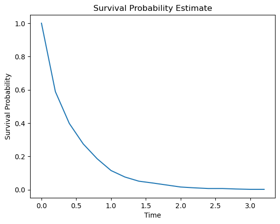

|  | time | survival |
| --- | --- | --- |
| 0 | 0.0 | 1.000 |
| 1 | 0.2 | 0.589 |
| 2 | 0.4 | 0.398 |
| 3 | 0.6 | 0.275 |
| 4 | 0.8 | 0.186 |
| 5 | 1.0 | 0.115 |
| 6 | 1.2 | 0.076 |
| 7 | 1.4 | 0.051 |
| 8 | 1.6 | 0.040 |
| 9 | 1.8 | 0.028 |
| 10 | 2.0 | 0.016 |
| 11 | 2.2 | 0.011 |
| 12 | 2.4 | 0.007 |
| 13 | 2.6 | 0.007 |
| 14 | 2.8 | 0.004 |
| 15 | 3.0 | 0.002 |
| 16 | 3.2 | 0.002 |

```python
import numpy as np
import matplotlib.pyplot as plt

# Generate survival times and censoring indicators
np.random.seed()
survival_times = np.random.exponential(scale=0.1, size=1000)
censored = np.random.binomial(1, 0.9, size=1000)
observed_times = np.minimum(survival_times, censored)*5

# Compute the survival function
time = np.arange(0, observed_times.max(), 0.2)
survival = np.array([(observed_times >= t).mean() for t in time])

# Plot the survival curve
plt.plot(time, survival)
plt.title("Survival Probability Estimate")
plt.xlabel("Time")
plt.ylabel("Survival Probability")
plt.show()

df = pd.DataFrame({'time': time, 'survival': survival})
df
```

# Confidence intervals

Confidence intervals are a range of values that is used to estimate an unknown population parameter with a certain level of confidence. In other words, a **confidence interval represents the range of values that is likely to contain the true value of the population parameter**. The level of confidence is expressed as a percentage, such as 95% or 99%, and indicates the probability that the true value falls within the interval.

For example, if you want to estimate the mean height of a population of people and take a sample of 100 individuals, you might calculate a 95% confidence interval for the population mean height. This interval would give you an estimate of the range of values that is likely to contain the true mean height of the population with 95% certainty.

In statistical analysis, confidence intervals help to provide a more complete picture of the uncertainty in estimates, and are used to make inferences about populations based on sample data.

# p-value

The p-value is a statistical measure that represents **the probability of obtaining a result as extreme or more extreme than the one observed, under the assumption that the null hypothesis is true**. The null hypothesis is often a statement of no effect or no difference, such as "there is no difference between the two groups" or "the treatment has no effect on the outcome."

A p-value less than a predetermined significance level, such as 0.05, indicates that the result is statistically significant and provides evidence against the null hypothesis. This means that the observed result is unlikely to have occurred by chance, and suggests that there is a real difference or effect present.

On the other hand, a p-value greater than the significance level indicates that the result is not statistically significant and provides insufficient evidence to reject the null hypothesis. In this case, the result may be due to chance or random variation, and further study may be needed to determine the true effect or difference.

# ICH E9

The ICH E9 guidelines are widely used by the pharmaceutical industry, regulatory agencies, and academic researchers, and are considered to be a benchmark for the conduct of high-quality clinical trials. The guidelines are regularly updated to reflect advances in the field and to ensure that they remain relevant and up-to-date.

- **Sample size estimation**: The guidelines provide recommendations for determining the sample size needed to detect a treatment effect with a specified level of power and significance.
- **Randomization**: The guidelines provide recommendations for the use of randomization in clinical trials, including methods for ensuring that the treatment groups are balanced and unbiased.
- **Blinded and unblinded trials**: The guidelines provide recommendations for the design of both blinded (single-blind, double-blind) and unblinded trials, and the advantages and disadvantages of each type of trial.
  - *Single-blind* usually means that the research participant is not told of the treatment assignment
  - *Double-blind* usually means that the research participant, investigator, study coordinator/nurse, study sponsor, and in some cases the data analyst are kept unaware of the treatment assignment.
- **Confounding**: The guidelines provide recommendations for controlling for confounding variables and ensuring that the results of the trial are not biased.
- **Interim analyses**: The guidelines provide recommendations for the conduct of interim analyses, including the use of stopping rules and the potential impact on the overall results of the trial.
- **Analysis and reporting**: The guidelines provide recommendations for the analysis and reporting of the results of clinical trials, including the use of appropriate statistical methods and the reporting of results in a clear and concise manner.

# FDA adaptive design guideline

The U.S. Food and Drug Administration (FDA) has issued guidance on the use of adaptive designs in clinical trials. Adaptive designs are flexible trial designs that allow for modifications to the study design or statistical analysis plan based on interim results. The aim of adaptive designs is to improve the efficiency and effectiveness of clinical trials by reducing the sample size, reducing the number of patients exposed to ineffective treatments, or increasing the likelihood of finding a significant effect, among other benefits.

The FDA's guidance on adaptive designs emphasizes the importance of proper planning, implementation, and reporting of adaptive trials to ensure the validity and reliability of the results. Key considerations include the study objectives, the underlying statistical and biological models, the criteria for modifying the trial, the potential impact of modifications on the overall validity and interpretation of the results, and the need for a pre-specified plan for data monitoring, analysis, and reporting.

The FDA also emphasizes the importance of clear communication and transparency about the adaptive design in the trial protocol, informed consent documents, and study reports, as well as the need for appropriate statistical methods to account for any modifications to the trial design.

Overall, the FDA recognizes the potential benefits of adaptive designs in clinical trials, but emphasizes the need for careful planning, implementation, and reporting to ensure the validity and reliability of the results.

## *Examples of those guidelines*

1. **Study Objectives**: The adaptive design should be driven by well-defined study objectives that are consistent with the regulatory goals and endpoints of the trial.
2. **Statistical and Biological Models**: The trial design and statistical methods should be based on sound scientific and statistical principles and take into account the underlying biology of the disease or condition being studied.
3. **Criteria for Modification**: The criteria for making modifications to the trial design should be clearly defined, pre-specified, and based on interim results or other relevant information.
4. **Data Monitoring**: A pre-specified plan for data monitoring and review should be in place to ensure the safety of the trial participants and to evaluate the trial's progress towards its objectives.
5. **Analysis and Reporting**: The statistical methods used to analyze the data and report the results should be specified in advance and take into account any modifications made to the trial design.
6. **Communication and Transparency**: The study protocol, informed consent documents, and study reports should clearly describe the adaptive design and any modifications made to the trial design.
7. **Validity and Reliability**: The validity and reliability of the results of an adaptive trial should be carefully considered and appropriately addressed in the study design, analysis, and reporting.

# FDA multiple endpoints guideline

The FDA has guidelines on the use of multiple endpoints in clinical trials, which are designed to ensure that the data collected is scientifically valid and robust. The goal is **to reduce the risk of false positive results, which can occur when multiple endpoints are analyzed simultaneously**. In simple terms, the FDA's guidelines suggest that multiple endpoints should be pre-specified, relevant to the research question, and analyzed with appropriate statistical methods that control the type I error rate. This helps to ensure that any observed treatment effects are not due to chance and are reliable and interpretable.

# EMA guidelines to consider on multiplicity

The European Medicines Agency (EMA) provides guidelines on multiplicity in clinical trials, known as Points to Consider on Multiplicity Issues in Clinical Trials. These guidelines provide recommendations for addressing multiple testing or multiple comparisons within a single clinical trial. The guidelines address issues such as:

1. Determining the primary and secondary endpoints of a study.
2. Defining a clear and justified approach to multiple testing and multiple comparisons.
3. Establishing an appropriate alpha correction or adjustment method to control for type 1 error rate.
4. Ensuring that all statistical inferences are made in a pre-specified manner.
5. Proper reporting of multiple testing and multiple comparisons, including all hypothesis tests performed, the results, and any correction or adjustment methods applied.

The EMA guidelines aim to promote transparent and scientifically rigorous practices in the analysis and interpretation of clinical trial data, and to ensure that clinical trial results are accurately and robustly supported.

# EMA subgroup analysis guideline.

The European Medicines Agency (EMA) provides guidelines on subgroup analysis in clinical trials, known as Points to Consider on Subgroup Analysis in Clinical Trials. These guidelines provide recommendations for addressing subgroup analysis in clinical trials and aim to promote transparent and scientifically rigorous practices in the conduct and interpretation of subgroup analyses. The guidelines address issues such as:

1. Defining a clear and justified approach to subgroup analysis.
2. Establishing a priori hypotheses for subgroup analysis, and clearly defining the subgroups of interest.
3. Conducting appropriate statistical tests for subgroup effects, including adjusting for multiple comparisons.
4. Ensuring that subgroup analyses are performed in a pre-specified manner and reported in the study protocol.
5. Proper reporting of subgroup analyses, including a clear and concise description of the subgroups, the results, and any limitations or caveats associated with the analysis.

The EMA guidelines aim to promote transparent and scientifically rigorous practices in the analysis and interpretation of clinical trial data, and to ensure that clinical trial results are accurately and robustly supported.